# Economic Impacts of Storms

GJAllen

March 2, 2018

### Synopsis

We want to answer the following questions.

1. Across the United States, which types of events (as indicated in the EVTYPE variable) are most harmful with respect to population health?
2. Across the United States, which types of events have the greatest economic consequences?

Because the purpose of this assignment is to learn about reproducible research rather than to actually do a great (and time consuming) analysis, I’m going to make a couple simplifying assumptions.  
I’m going to assume that the only form of economic consequence that we care about is property damage, and that the only form of health consequence we care about is injuries.

### Reading in the data

```r
suppressMessages(library(tidyverse, warn.conflicts = FALSE))
library(lubridate, warn.conflicts = FALSE)
library(magrittr, warn.conflicts = FALSE)
```

```r
storm.data <- read.csv("C:/Users/u55a20/Downloads/StormData.csv.bz2")
head(storm.data)
```

```
##   STATE__           BGN_DATE BGN_TIME TIME_ZONE COUNTY COUNTYNAME STATE
## 1       1  4/18/1950 0:00:00     0130       CST     97     MOBILE    AL
## 2       1  4/18/1950 0:00:00     0145       CST      3    BALDWIN    AL
## 3       1  2/20/1951 0:00:00     1600       CST     57    FAYETTE    AL
## 4       1   6/8/1951 0:00:00     0900       CST     89    MADISON    AL
## 5       1 11/15/1951 0:00:00     1500       CST     43    CULLMAN    AL
## 6       1 11/15/1951 0:00:00     2000       CST     77 LAUDERDALE    AL
##    EVTYPE BGN_RANGE BGN_AZI BGN_LOCATI END_DATE END_TIME COUNTY_END
## 1 TORNADO         0                                               0
## 2 TORNADO         0                                               0
## 3 TORNADO         0                                               0
## 4 TORNADO         0                                               0
## 5 TORNADO         0                                               0
## 6 TORNADO         0                                               0
##   COUNTYENDN END_RANGE END_AZI END_LOCATI LENGTH WIDTH F MAG FATALITIES
```

[output cut: 20 more lines]

There are lots of different types of Events Types, and many appear to be closely related.  
Take THUNDERSTORM WIND vs THUNDERSTORN WINDS as an example, or even LIGHTNING, which we expect to coincide with thunderstorms.

```r
length(unique(storm.data$EVTYPE))
```

```
## [1] 985
```

```r
table(storm.data$EVTYPE) %>% sort %>% tail(20)
```

```
##
##                 WILDFIRE     URBAN/SML STREAM FLD              STRONG WIND
##                     2761                     3392                     3566
##               WATERSPOUT MARINE THUNDERSTORM WIND         MARINE TSTM WIND
##                     3796                     5812                     6175
##             FUNNEL CLOUD           WINTER WEATHER             WINTER STORM
##                     6839                     7026                    11433
##               HEAVY RAIN               HEAVY SNOW                LIGHTNING
##                    11723                    15708                    15754
##                HIGH WIND       THUNDERSTORM WINDS                    FLOOD
##                    20212                    20843                    25326
##              FLASH FLOOD                  TORNADO        THUNDERSTORM WIND
##                    54277                    60652                    82563
##                TSTM WIND                     HAIL
##                   219940                   288661
```

At this point we would want to determine some logic to roll up individual EVTYPEs into related categories, or to use a dimension reduction technique and to work from newly derived variable(s).  
But that is too much work, so we’re just going to pretend that event types are all unrelated, and ignore any with fewer than an arbitrary number of associated records.

```r
table(storm.data$EVTYPE) %>% quantile(0:100/100)
```

```
##        0%        1%        2%        3%        4%        5%        6%
##      1.00      1.00      1.00      1.00      1.00      1.00      1.00
##        7%        8%        9%       10%       11%       12%       13%
##      1.00      1.00      1.00      1.00      1.00      1.00      1.00
##       14%       15%       16%       17%       18%       19%       20%
##      1.00      1.00      1.00      1.00      1.00      1.00      1.00
##       21%       22%       23%       24%       25%       26%       27%
##      1.00      1.00      1.00      1.00      1.00      1.00      1.00
##       28%       29%       30%       31%       32%       33%       34%
##      1.00      1.00      1.00      1.00      1.00      1.00      1.00
##       35%       36%       37%       38%       39%       40%       41%
##      1.00      1.00      1.00      1.00      1.00      1.00      1.00
##       42%       43%       44%       45%       46%       47%       48%
##      1.00      1.00      1.00      1.00      1.00      1.00      1.00
##       49%       50%       51%       52%       53%       54%       55%
##      1.00      2.00      2.00      2.00      2.00      2.00      2.00
##       56%       57%       58%       59%       60%       61%       62%
##      2.00      2.00      2.00      2.00      2.00      2.00      2.00
##       63%       64%       65%       66%       67%       68%       69%
##      2.00      3.00      3.00      3.00      3.00      3.00      3.00
##       70%       71%       72%       73%       74%       75%       76%
##      3.80      4.00      4.00      4.00      4.00      5.00      5.00
##       77%       78%       79%       80%       81%       82%       83%
##      5.00      6.00      6.00      7.00      8.00      8.00      9.72
##       84%       85%       86%       87%       88%       89%       90%
##     11.00     13.00     16.24     19.08     22.92     26.76     35.20
##       91%       92%       93%       94%       95%       96%       97%
##     47.44     61.84     98.36    153.76    258.80    595.32   1014.48
##       98%       99%      100%
##   2732.44  12360.60 288661.00
```

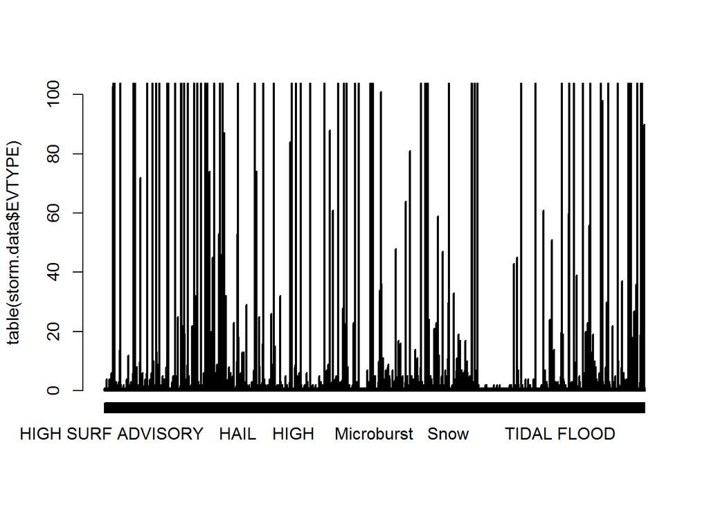

```r
plot(table(storm.data$EVTYPE), ylim = c(0, 100))
```

20 looks like a fine threshold.

```r
dim(storm.data)
```

```
## [1] 902297     37
```

```r
storm.data %<>%
  group_by(EVTYPE) %>%
  mutate(n = n()) %>%
  ungroup %>%
  filter(n > 20)
dim(storm.data)
```

```
## [1] 900032     38
```

### Results

Let’s look at the most severe weather events for property damage and injuries

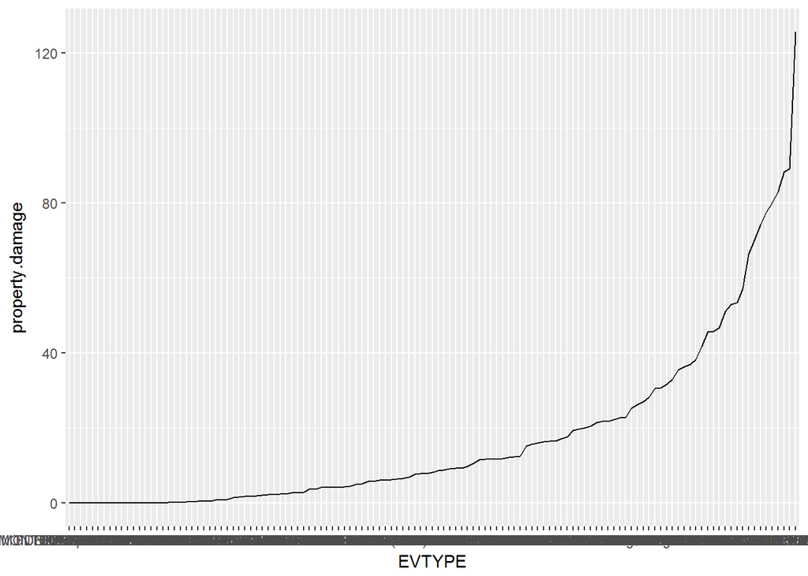

```r
storm.data %>%
  group_by(EVTYPE) %>%
  summarize(injuries = mean(INJURIES),
            property.damage = mean(PROPDMG)) %>%
  mutate(EVTYPE = reorder(EVTYPE, property.damage)) %>%
  ggplot() +
  aes(EVTYPE, property.damage) +
  geom_line(group = "identity")
```

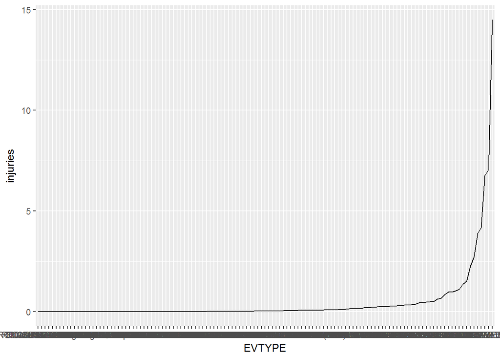

```r
storm.data %>%
  group_by(EVTYPE) %>%
  summarize(injuries = mean(INJURIES),
            property.damage = mean(PROPDMG)) %>%
  mutate(EVTYPE = reorder(EVTYPE, injuries)) %>%
  ggplot() +
  aes(EVTYPE, injuries) +
  geom_line(group = "identity")
```

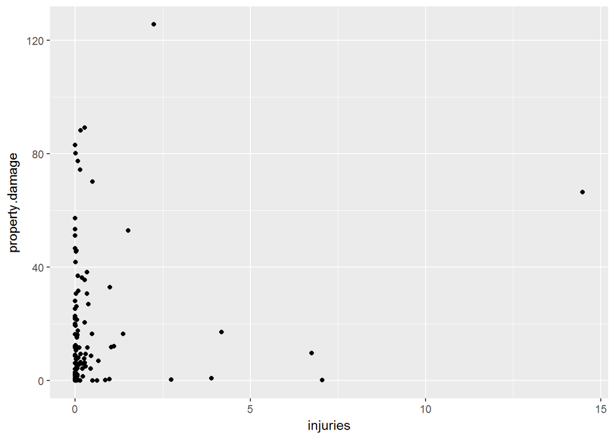

```r
storm.data %>%
  group_by(EVTYPE) %>%
  summarize(injuries = mean(INJURIES),
            property.damage = mean(PROPDMG)) %>%
  ggplot() +
  aes(injuries, property.damage) +
  geom_point()
```

So what are the most damaging weather events with respect to property damage?

```r
storm.data %>%
  group_by(EVTYPE) %>%
  summarize(injuries = mean(INJURIES),
            property.damage = mean(PROPDMG),
            n = mean(n)) %>%
  arrange(desc(property.damage)) %>%
  head()
```

```
## # A tibble: 6 x 4
##              EVTYPE   injuries property.damage     n
##              <fctr>      <dbl>           <dbl> <dbl>
## 1               ICE 2.24590164       125.57377    61
## 2         HURRICANE 0.26436782        89.15908   174
## 3       HEAVY RAINS 0.15384615        88.27115    26
## 4 FLASH FLOOD/FLOOD 0.00000000        83.04091    22
## 5       RIVER FLOOD 0.01156069        80.09075   173
## 6    EXCESSIVE SNOW 0.08000000        77.40000    25
```

How bout in the most hazardous for human health?

```r
storm.data %>%
  group_by(EVTYPE) %>%
  summarize(injuries = mean(INJURIES),
            property.damage = mean(PROPDMG),
            n = mean(n)) %>%
  arrange(desc(injuries)) %>%
  head()
```

```
## # A tibble: 6 x 4
##              EVTYPE  injuries property.damage     n
##              <fctr>     <dbl>           <dbl> <dbl>
## 1 HURRICANE/TYPHOON 14.488636      66.3564773    88
## 2      EXTREME HEAT  7.045455       0.2322727    22
## 3             GLAZE  6.750000       9.7062500    32
## 4         HEAT WAVE  4.175676      17.1520270    74
## 5    EXCESSIVE HEAT  3.888558       0.8700834  1678
## 6              HEAT  2.737940       0.3891786   767
```

### Conclusion

Ice, hurricane, heavy rains, floods, and excessive snow are associated with the most property damage.  
Hurricanes and extreme heat are associated with the most injuries.